# EP03-respuesta-equipo-9

Francisca Cavieres y Diego Guerra

2025-09-03

# Actividad 3

**Para esta actividad, se usa como base el siguiente contexto:**

En una planta química hay dos máquinas que envasan detergentes industriales en bidones con un volumen de producto que sigue una distribución normal con **desviación estándar de 1 litro.** La ingeniera a cargo de la planta debe asegurar que los bidones se están llenando con una **media de 10 litros.** Pero ella tiene la sospecha de que hay desviaciones en esta media, lo que piensa confirmar usando una **muestra aleatoria de 100 envases** (50 de cada una de las máquinas). También cree que hay diferencia en el cumplimiento del volumen requerido entre la máquina más antigua y la más moderna, que han de andar por el **90% y 96%** de los bidones, respectivamente.

## Desarrollo

Se comienza por importar las librerías a utilizar a lo largo del código

```r
library(ggpattern)
library(ggpubr)
library(ggplot2)
library(pwr)
```

Luego, se definen variables globales en base a los datos entregados en el contexto y en las preguntas.

```r
n <- 100   # Cantidad de muestras

media_nula <- 10    # Valor nulo asociado a la hipótesis nula

sigma <- 1    # Desviación estándar

x_crit <- 9.81 # Valor crítico para el cual se hace la comparación

media_verdadera <- 9.9  # Media verdadera del problema
```

### Pregunta 1

Si la ingeniera está seguro de que el verdadero volumen medio no puede ser superior a 10 litros y **piensa rechazar la hipótesis nula cuando la muestra presente una media menor a 9,81 litros**, ¿cuál es la probabilidad de que cometa un **error de tipo I**? Para responder, generen un gráfico de la distribución muestral de las medias hipotetizada en donde se marque la zona correspondiente a la probabilidad solicitada, para luego, basándose en este gráfico, calcular el área correspondiente. Tome como ejemplo los scripts presentados en la lectura sobre poder estadístico.

- En este pregunta, se pide calcular la probabilidad de cometer un error tipo I, es decir, se pide calcular el nivel de significación con los datos que entrega el enunciado. Para esto, se debe calcular el area bajo la curva de la sección correspondiente en el grafico generado.

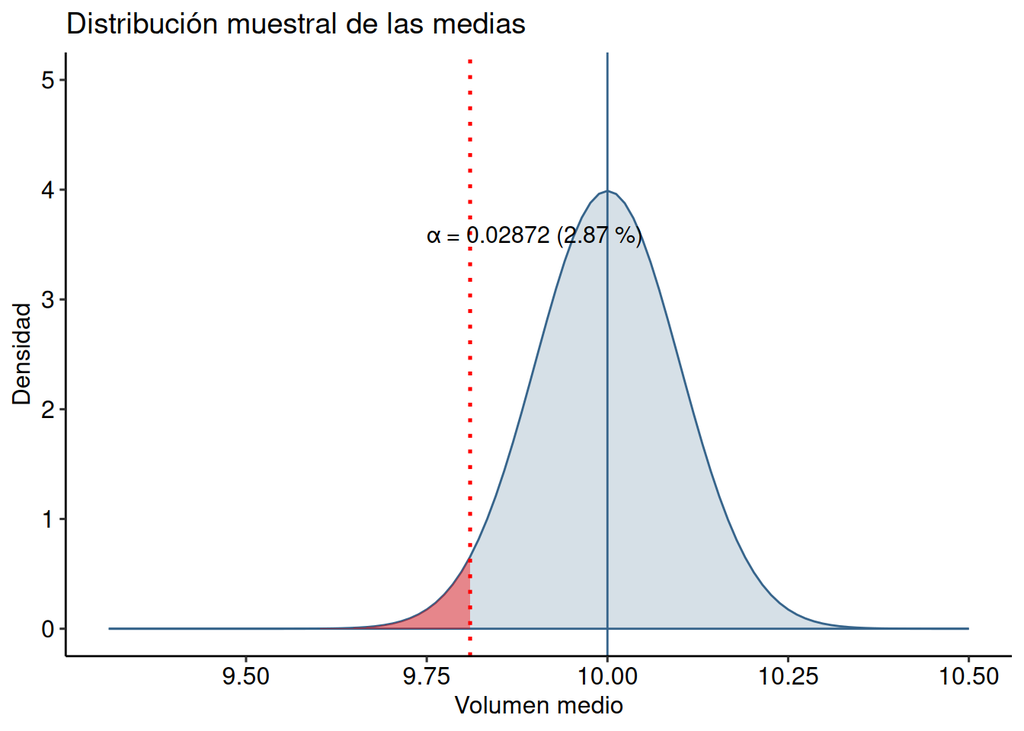

```r
SE <- sigma / sqrt(n) # Error estándar

z <- (x_crit - media_nula) / SE # Valor buscado normalizado

alpha <- pnorm(z) # Valor correspondiente al nivel de significacia

g_x_limites <-  media_nula + c(-6.9, 5) * SE # Límites establecidos para el gráfico

g <- ggplot() + xlim(g_x_limites) + ylim(c(0, 5)) # Límites para el gráfico en ambos ejes

g <- g + labs(title = "Distribución muestral de las medias")

g <- g + labs(x = "Volumen medio", y = "Densidad")

g <- g + theme_pubr()

dist_0 <- stat_function(fun = dnorm, geom = "area",
                       args = list(mean = media_nula, sd = SE),
                       colour = "steelblue4", fill = "steelblue4", alpha = 0.2)
g1 <- g + dist_0

g1 <- g1 + geom_vline(xintercept = media_nula, colour = "steelblue4")

g1 <- g1 + geom_vline(xintercept = x_crit, colour = "red", linetype = "dotted", size = 0.9) # Se agrega una línea que corresponde al intercepto de la zona crítica del problema

z_critico_inferior <- x_crit

g2 <- g1 + stat_function(fun = dnorm, geom = "area",
                         args = list(mean = media_nula, sd = SE),
                         xlim = c(g_x_limites[1], z_critico_inferior),
                         fill = "red", alpha = 0.4) # Se rellena la zona


x_vals <- seq(g_x_limites[1], g_x_limites[2], length.out = 1000)

maxy <- max(dnorm(x_vals, mean = media_nula, sd = SE))

g2 <- g2 + annotate("text",
                    x = media_nula - 2.5*SE,
                    y = maxy * 0.90,
                    label = sprintf("α = %.5f (%.2f %%)", alpha, alpha*100),
                    hjust = 0, size = 4) # Se muestra el valor de alfa en el gráfico

print(g2)
```

**Primero**, es importante mencionar que el valor buscado se ha normalizado con el fin de obtener el resultado con una **distribución Z estándar**. De esta forma, se obtiene que la probabilidad de cometer un **error tipo I es de 2.87%.**

Desde el punto de vista de una prueba de contraste de hipótesis, se trata de un **valor bastante exigente**, considerando que en general se utilizan valores como 0,05. Es decir, existe una **probabilidad del 2,87%** de que detecte que el volumen medio de los bidones es **menor a 9.81, cuando en realidad no lo es.**

### Pregunta 2

Si el **verdadero volumen medio de los bidones fuera de 9,9 litros**, ¿cuál sería la probabilidad de que la ingeniera, que obviamente no conoce este dato, cometa un **error de tipo II?** Para responder, agregue al gráfico anterior la verdadera distribución muestral de las medias y marquen (con otro color) la zona correspondiente a la probabilidad solicitada, para luego, basándose en este gráfico, calcular el área correspondiente. También hay ejemplos de este procedimiento en la lectura sobre poder estadístico.

- En esta pregunta, se pide calcular la probabilidad de cometer un **error tipo II.** Esto se logra a través del **cálculo de $\beta$,** haciendo uso de graficos y area bajo la curva. El $\beta$ obtenido será directamente la probabilidad de cometer este tipo de error.

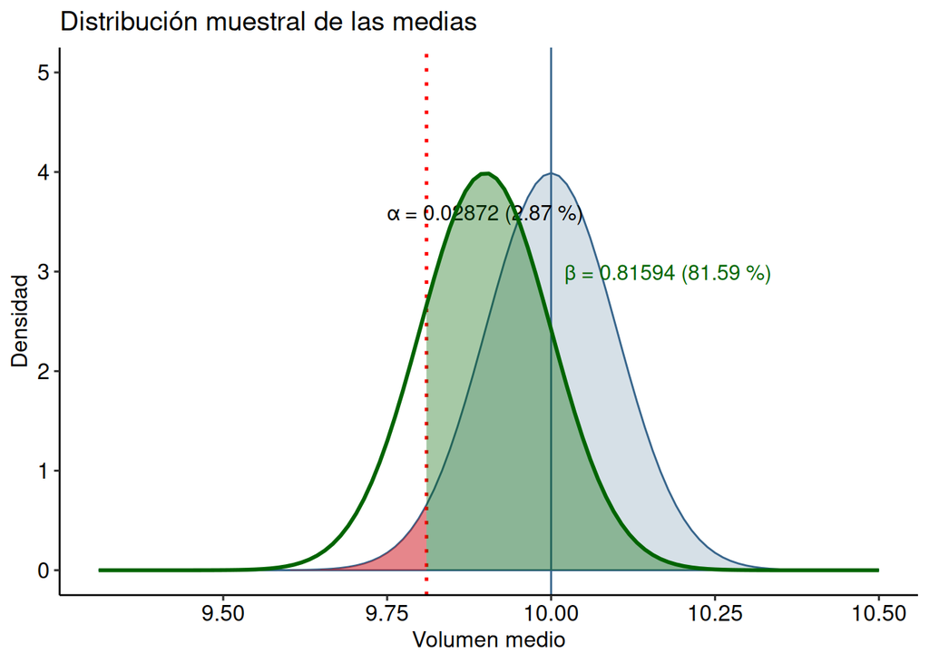

```r
z_alt <- (x_crit - media_verdadera) / SE

power <- pnorm(z_alt)

beta <- 1 - power

g2 <- g2 + stat_function(fun = dnorm, geom = "line",
                         args = list(mean = media_verdadera, sd = SE),
                         colour = "darkgreen", linewidth = 1.0)


g3 <- g2 + stat_function(fun = dnorm, geom = "area",
                         args = list(mean = media_verdadera, sd = SE),
                         xlim = c(x_crit, g_x_limites[2]),
                         fill = "darkgreen", alpha = 0.35)


g3 <- g3 + annotate("text",
                    x = media_verdadera + 1.2*SE,
                    y = maxy * 0.75,
                    label = sprintf("β = %.5f (%.2f %%)", beta, beta*100),
                    hjust = 0, size = 4, colour = "darkgreen")

print(g3)
```

Es posible observar que la **probabilidad de cometer un error tipo II es del 81,59%,** lo cual concuerda con lo obtenido anteriormente respecto a la significación, ya que este es bastante exigente. Es relevante notar que la probabilidad de error tipo II es alta, lo cual significa que es muy probable que no se detecte un efecto real si es que existe. Lo anterior, dada la relación entre el **poder y $\beta$.**

**p = 1-$\beta$**

### Pregunta 3

Como **no se conoce el verdadero volumen medio**, genere un gráfico del poder estadístico con las condiciones anteriores, pero suponiendo que el **verdadero volumen medio podría variar de 9,6 a 10 litros.** Hay un ejemplo de este tipo de gráfico en la lectura sobre poder estadístico.

- En esta pregunta, se pide graficar el **comportamiento del poder a medida que cambia el tamaño del efecto** en la prueba. Lo anterior, dado que **se cambia la media real** que se debe considerar en el problema, por lo que **el parámetro que se ve afectado por esta variación es el tamaño del efecto.**

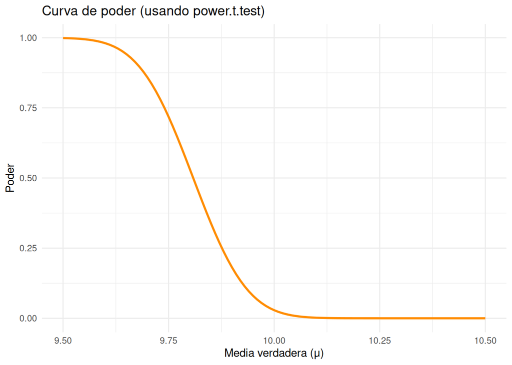

```r
sig.level <- pnorm((x_crit - media_nula) / (sigma/sqrt(n)))

medias_verdaderas <- seq(9.5, 10.5, by = 0.01)

poder_ptest <- sapply(medias_verdaderas, function(mu){
  diff <- media_nula - mu
  res <- power.t.test(n = n, delta = diff, sd = sigma,
                      sig.level = sig.level,
                      type = "one.sample",
                      alternative = "one.sided")
  res$power
})


df_poder_ptest <- data.frame(mu = medias_verdaderas, poder = poder_ptest)


ggplot(df_poder_ptest, aes(x = mu, y = poder)) +
  geom_line(color = "darkorange", size = 1) +
  labs(title = "Curva de poder (usando power.t.test)",
       x = "Media verdadera (μ)",
       y = "Poder") +
  theme_minimal()
```

En el gráfico anterior, es posible observar una relación clara entre la diferencia de las medias verdaderas y el poder de la prueba. **A mayor sea la media verdadera, menor será el poder asociado a la prueba.**

Esto tiene sentido, puesto que uno de los factores en el cálculo del tamaño del efecto es $\delta$, que corresponde a la diferencia entre las medias. Lo anterior, se ve de la siguiente forma:

$$d = \frac{\delta}{\sigma}$$
Donde

$$\delta = \mu - \mu_0$$
Es decir, mientras más grande sea la diferencia entre el centro de la distribución hipotética y verdadera, crecerá el área de rechazo en la distribución verdadera. Lo anterior implica un aumento en la potencia de la prueba.

Como en esta pregunta se trata con una **prueba unlitateral**, tiene sentido que la línea del gráfico decaiga a medida que crece esta diferencia, ya que **cuando el efecto crece en favor de la hipótesis nula la probabilidad que el efecto sea detectado disminuyen** considerablemente.

### Pregunta 4

Considerando un **volumen medio de 10 litros,** ¿cuántos bidones deberían revisarse para conseguir un **poder estadístico de 0,7** y un **nivel de significación de 0,05**?

- En este pregunta **se pide calcular el tamaño de la muestra**, la que se obtendrá con los valores que se entregan. Lo anterior es fácilmente deducible dados los parámetros que se necesitan para calcular el poder de una prueba.

Para obtener el valor anterior, se lleva a cabo una prueba de poder asociado a una prueba t, donde se deja el **parámetro n = NULL**, este n corresponde al tamaño de la muestra, de esta forma la prueba entrega un resultado para este mismo.

```r
delta <- media_verdadera - media_nula
sigma <- 1
d <- delta/sigma

sig.level <- 0.05
power.target <- 0.7

res <- pwr.t.test(n = NULL,
                  d = d,
                  sig.level = sig.level,
                  power = power.target,
                  type = "one.sample",
                  alternative = "less")

res
```

```
##
##      One-sample t test power calculation
##
##               n = 471.9218
##               d = -0.1
##       sig.level = 0.05
##           power = 0.7
##     alternative = less
```

Observando el resultado, **se concluye que la cantidad de bidones necesarios para poder llevar a cabo una prueba con un nivel de significación de 0.05 y poder de 0.7, son 472**. Se redondea al número entero superiormente más cercano puesto que la cantidad de bidones debe ser entera. Además, considerando lo mencionado en el contexto del problema, donde ambas máquinas tienen la misma cantidad de bidones, se concluye que **ambas máquinas recibirán 236 bidones respectivamente.**

### Pregunta 5

¿**Alcanzaría esta muestra para detectar la diferencia** que la ingeniera sospecha que existe entre las dos máquinas de la planta con al menos las mismas probabilidades de cometer errores?

- En esta pregunta, se pide calcular la magnitud de la diferencia de proporciones de ambas máquinas. Para esto, se utilizan los parámetros obtenidos en las preguntas anteriores, además de dividir el tamaño obtenido en 2, puesto que se menciona en el contexto que cada máquina tiene la misma cantidad de bidones.

Considerando el valor que se quiere conocer, **se deja en nulo el valor de h**. Es decir, **se quiere conocer la magnitud del tamaño del efecto para la diferencia de proporciones de ambas pruebas.**

Para llevar a cabo lo anterior, se establecen las siguiente hipótesis, consdierando $p_{M_1}$ la probabilidad de cumplimento de la máquina 1, y $p_{M_2}$ la probabilidad de cumplimiento de la máquina 2:

$$H_0: p_{M_1} = p_{M_2}$$
$H_0:$ La probabilidad de cumplimiento de las máquinas es similar

$$H_A: p_{M_1} < p_{M_2}$$
$H_A:$ La probabilidad de cumplimiento de la máquina 2 es mayor a la de la máquina 1

```r
preg5 <- pwr.2p.test(h = NULL, n = 236, alpha, power = power.target, alternative =  "greater" )
preg5
```

```
##
##      Difference of proportion power calculation for binomial distribution (arcsine transformation)
##
##               h = 0.2231625
##               n = 236
##       sig.level = 0.02871656
##           power = 0.7
##     alternative = greater
##
## NOTE: same sample sizes
```

De esta forma, se extrae de la prueba que la **diferencia entre las propociones** de cada máquina es estádisticamente pequeña, **con un 0.22**, apenas sobre el umbral del 0.2. **Si bien existe una diferencia, esta es dificilmente detectable con la muestra disponible**, es decir, la diferencia entre las proporciones es apenas perceptible con el tamaño de muestra usado. Una diferencia en las proporciones tan pequeña puede significar que esta diferencia tiene **poca relevancia práctica en el mundo real**.